# 260-2016-11-07

2016-11-07 10:27:04

## Prelude

[video not shown]

## Tomorrow

- [Find your polling place](http://centrecountypa.gov/index.aspx?nid=243)

## ID requirements (first time voting in precinct)

- Photo ID issued by any Pennsylvania agency or the US government
- US passport
- US Armed Forces ID
- Student ID
- Employee ID
- Confirmation from a county voter registration office
- Non-photo ID issued by Pennsylvania or the US government
- Firearm permit
- Current utility bill, bank statement, paycheck, or government check

## Who pays for [neuroscience research](https://www.sfn.org/advocacy/neuroscience-funding/us-funding-priorities/us-neuroscience-funding-process)

- You do!
- U.S. National Institutes of Health, ~$32 billion for all diseases in 2016
- U.S. National Science Foundation, ~$7.46 billion for all sciences

## Today's Topics

- Wrap up on [sensory systems](https://rawgit.com/psu-psychology/psych-260/master/lectures/260-2016-11-04.html#20)
- Somatosensation

## Types of somatosensation

- Internal (interoceptive)
  - Where am I? How do I feel?
  - Proprioception
- External (exteroceptive)
  - What’s in the world?
  - Where is it?

## Internal senses

- Vestibular sense
  - Head position
  - Head movement (rotation, translation)
- Kinesthesia
  - Body position
  - Movement
- Pain

## External senses

- Cutaneous senses (touch)
  - Hot, cold
  - Pressure
  - Vibration
  - Damage (pain)
- Plus kinesthesia (why?)

## Cutaneous receptors

[figure not shown]

## Receptors specialize

[figure not shown]

[figure not shown]

## Combined thermo and chemo receptors

- Why are spicy foods hot?
- Why are minty foods cool?

## Combined thermo and chemo receptors

- Menthol/mint receptor (CMR1)
  - Also signals "cool"
- Vanilloid Receptors (VR1, VRL1)
  - Also signal "hot
  - Capsaicin

## Menthol & vanilloid receptors

[figure not shown]

## Size/speed trade-off

[figure not shown]

## From skin to brain

- Cutaneous receptors
- Dorsal root ganglion
- Ventral posterior lateral thalamus
- Primary somatosensory cortex (S1)
  - Parietal lobe

## Dermatomes

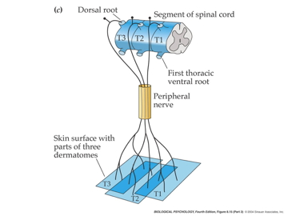

## Dermatomes

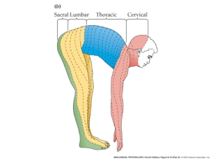

## Functional segregation

[figure not shown]

## Functional segregation

- Dorsal column/medial leminiscal pathway
  - Touch, proprioception
- Spinothalamic tract
  - Pain, temperature

## Somatatopic maps

[figure not shown]

## Non-uniform mapping of skin surface

[figure not shown]

## Non-uniform mapping of skin surface

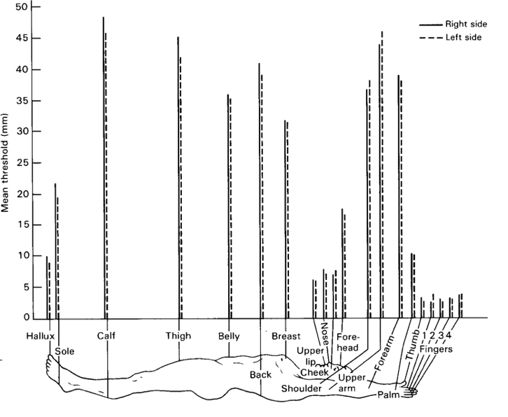

http://jov.arvojournals.org/data/Journals/JOV/933499/jov-3-10-1-fig001.jpeg

## Columnar organization/functional segregation

[figure not shown]

## Phantom Limbs

[video not shown]

## What/where

- Perceiving Where
  - Somatotopic maps – where on skin
  - Kinesthesia – configuration of limbs
- Perceiving What
  - Patterns of smoothness, roughness, shape, temperature

## Somatosensation in other animals

[figure not shown]

## Next time…

- The "real" reason for brains